# Prediction of manner of exercise

### Method 2 : random forest model

Now moved on to random forest model which was more slower algorithm than rPart but more powerful. Again 10-fold cross validation was used with default options.

```r
set.seed(40)
rfModel <- train(classe ~ ., data=train1, method="rf", trControl=trainControl(method="cv"))
```

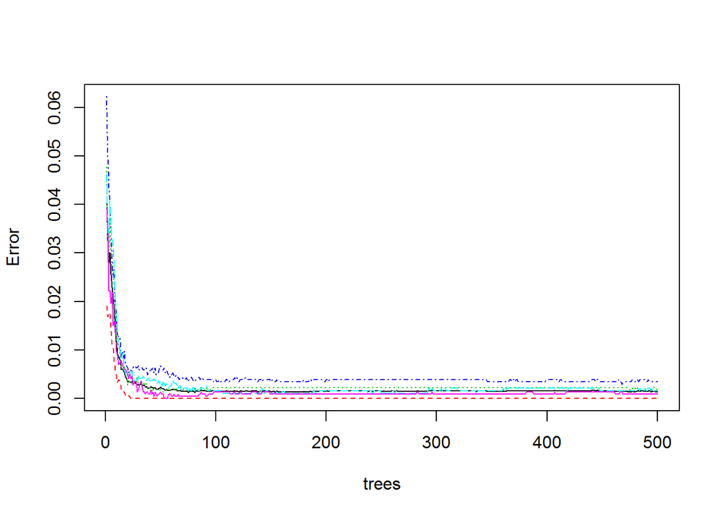

```r
  plot(rfModel$finalModel, main="")
```

```r
rfTrainPred <- predict(rfModel, newdata=train1)
rfTestPred <- predict(rfModel, newdata=test1)
rfTrainingConfusion <- confusionMatrix(train1$classe, rfTrainPred)
rfTrainingConfusion$overall[1] #Accuracy :1
rfTestingConfusion <- confusionMatrix(test1$classe, rfTestPred)
rfTestingConfusion$overall[1]  #Accuracy :0.9983431
```

```r
  print(testingConfusion$table)
```

[output not shown]

### Method 3 : Generalized Boosted Regression Modeling

The results from random forest were highly accurate but in an attempt to reduce the time needed to train the model. Use boosting which uses similar concepts than random forest but uses weak predictors and weigh them based on their accuracy to get similar results with simple trees rather than making complex trees. Using 10-fold cross validation was used with default options.

```r
set.seed(50)
gbmModel <- train(classe ~ ., data=train1, method="gbm", trControl=trainControl(method="cv"))
```

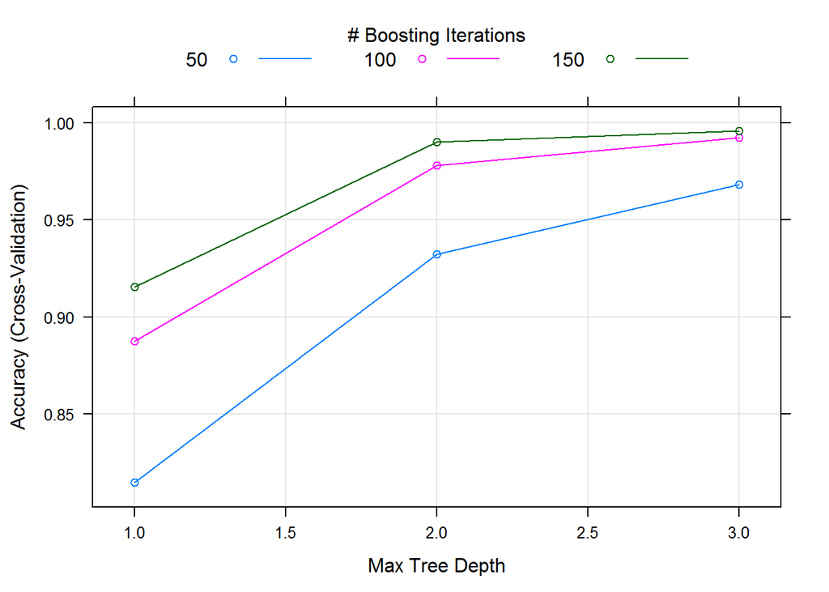

```r
plot(gbmModel)
```

```r
gbmTrainPred <- predict(gbmModel, newdata=train1)
gbmTestPred <- predict(gbmModel, newdata=test1)
gbmTrainingConfusion <- confusionMatrix(train1$classe, gbmTrainPred)
gbmTrainingConfusion$overall[1] #Accuracy : 0.9987262
gbmTestingConfusion <- confusionMatrix(test1$classe, gbmTestPred)
gbmTestingConfusion$overall[1] #Accuracy : 0.9949019
```

```r
print(gbmTestingConfusion$table)
```

```
##           Reference
## Prediction    A    B    C    D    E
##          A 2232    0    0    0    0
##          B    8 1509    1    0    0
##          C    0    2 1362    4    0
##          D    0    0   10 1272    4
##          E    0    0    0   14 1428
```

From above results, it is seen that in-sample error accuracy is 99.87% and out-sample error accuracy is 99.47%. There were more errors and the performance deteriorated a little as compared to random forest. It found 3 times better in terms of time but marginally worse in term of accuracy.